# Tarea3_CristobalCampos

Cristobal Campos

06-12-2021

```r
library(tidyverse)
library(palmerpenguins)
library(paletteer)
```

## Introducción

Lo invito a ver este tutoria donde aprenderemos a realizar paletas de colores y modificaciones de temas para un gráfico de de barras y utilizando un theme de ggplot2. sin mas preambulos lo invito a deleitarse con este interactivo tutorial.

## Primera parte

En una primera instancia crearemos un grafico por defecto de la base de datos “penguins” para luego realizar modificaciones, asignando el objeto con el nombre barras1. De la siguiente función obtendremos el siguiente el gráfico.

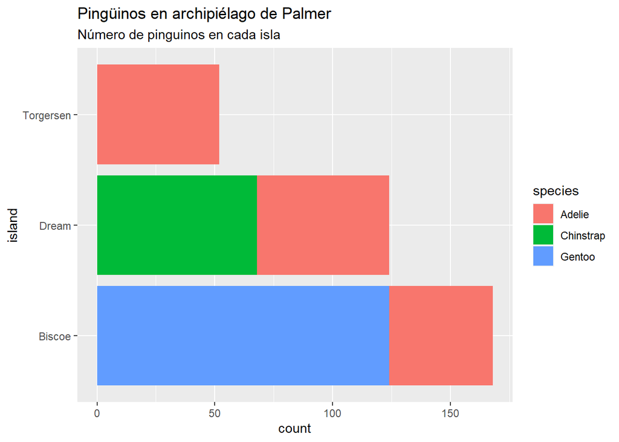

```r
barras1 <- ggplot(penguins, aes(y = island, fill = species)) +
  geom_bar() +
  labs(title = "Pingüinos en archipiélago de Palmer",
       subtitle = "Número de pinguinos en cada isla")

barras1
```

# Crearemos nuestra paleta y la modificaremos!! sera genial

comenzaremos escogiendo nuestra paleta con con la función paletteer_d

Para este ejemplo utilizaremos la paleta “calecopal::fire”

```r
library(paletteer)

paletteer_d("calecopal::fire")
```

```
## <colors>
## #B77B7BFF #FEEC44FF #F66C09FF #E60505FF #2C1B21FF
```

Luego de eso asignaremos como paleta1 la paleta escogida para este tutorial

```r
paleta1 <- c("#B77B7BFF", "#FEEC44FF", "#F66C09FF", "#E60505FF", "#2C1B21FF")
```

y obtener asi los siguientes graficos

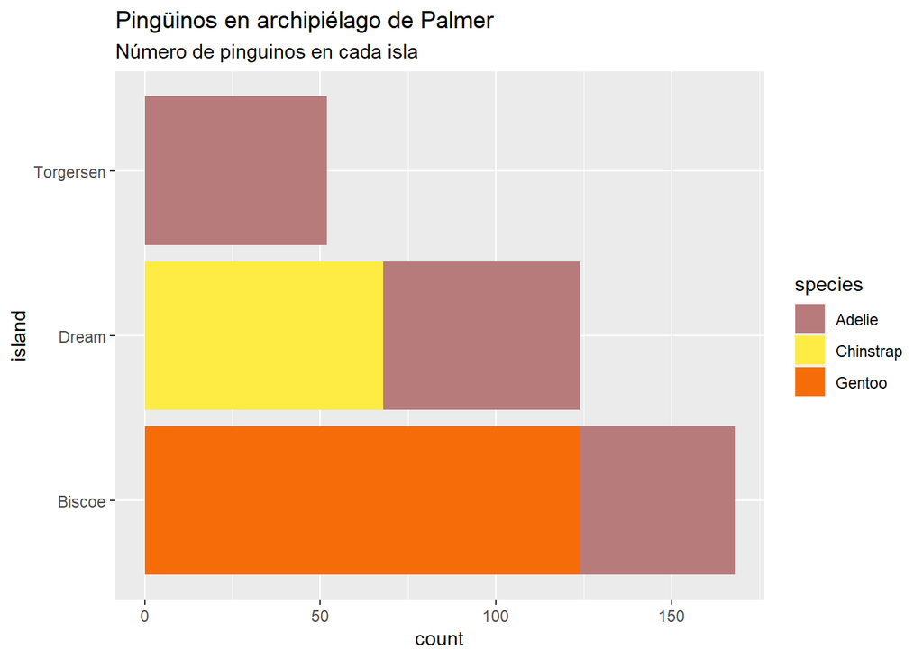

```r
fill1 <- scale_fill_manual(values = paleta1)

barras1 + scale_fill_manual(values = paleta1)
```

Ahora que logramos cambiar de color las barras te invito a que busques inspiración para crear tu propia paleta siguiendo el siguiente link:

https://emilhvitfeldt.github.io/r-color-palettes/discrete.html

Puedes modificar tu grafico de barras solo cambiando los valores de las funciones descritas anteriormente.

## Tercera parte

Te gusto el link, bien, ahora que tenemos nuestras barras listas seria bueno cambiar un poco el tamaño y color de los titulos y subtitulos, para eso utilizaremos la siguiente función, usted podra cambiar el tamaño cambiando el valor en la función “size” y el color en la función color

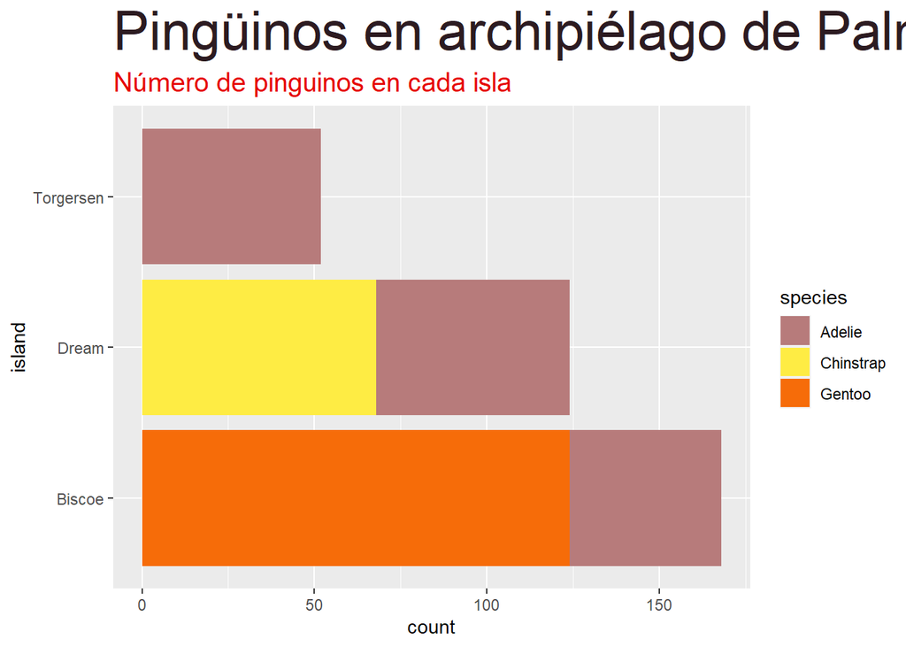

```r
barras1 + scale_fill_manual(values = paleta1) +
  theme(
  plot.title = element_text(size = 30, color = "#2C1B21FF" ),
  plot.subtitle = element_text(size = 15, color = "#E60505FF")
)
```

Y listo, con estas simples funciones podras presentar un gráfico.

Ahora es tu turno intentarlo.